# R Studio Conference 2019, Austin

Govind Nair

2/2/2019

This is a notebook summarizing what I learned at the R Studio Conference 2019. Snippets of code and links to further resources have also been provided.I am restricting the content here to what is relevant to us at Key given the extent to which we use R. Links to all the talks and slide decks,inlcuding talks on how to use R in production at scale are available at https://github.com/kbroman/RStudioConf2019Slides

Before stating make sure the following packages have been installed: 1) reprex 2) tidyselect 3) dplyr 4) ggplot2 5) sunburstR 6) gganimate

## Reproducible Examples with reprex

The reprex package allows you to create a minimal reproducible example that you can share if you are reporting an issue on Github or asking a question on stack overflow. Running the code chunk below after uncommenting will create a new web page with the code and the results that can be shared with others.

```r
# reprex({
#   x <- 1:4
#   y <- 2:5
#   x + y
# })
```

## Categorical data in R

Factor variables in R can be idiosyncratic

```r
x <- c(20,20,10,40,20)
cat(x)
```

```
## 20 20 10 40 20
```

Converting this to a factor variable produces the following

```r
xf <- factor(x)
xf
```

```
## [1] 20 20 10 40 20
## Levels: 10 20 40
```

Converting this factor back to numeric produces the following odd result

```r
x <- as.numeric(xf)
x
```

```
## [1] 2 2 1 3 2
```

The right way to catty out this conversion is as follows

```r
x <- as.numeric(as.character(xf))
x
```

```
## [1] 20 20 10 40 20
```

One also needs to be careful while re-ordering the levels of a factor

```r
ratings1<-  as.factor(c(rep('High',30),rep('Low',10),rep('Medium',20)))
ratings2 <- ratings1
ratings3 <- ratings1
table(ratings1)
```

```
## ratings1
##   High    Low Medium
##     30     10     20
```

```r
cat('Levels: \n')
```

```
## Levels:
```

```r
cat(levels(ratings1))
```

```
## High Low Medium
```

We might want to change the levels of this variable to be Low,Medium,High

The next couple of approaches do not yield expected results.

```r
levels(ratings1) <- levels(ratings1)[c(2,1,3)]
table(ratings1)
```

```
## ratings1
##    Low   High Medium
##     30     10     20
```

```r
levels(ratings2) <- c('Low','Medium','High')
table(ratings2)
```

```
## ratings2
##    Low Medium   High
##     30     10     20
```

The correct approach here would be as follows

```r
ratings3 <- factor(ratings3,levels=c('Low','Medium','High'))
table(ratings3)
```

```
## ratings3
##    Low Medium   High
##     10     20     30
```

The **forcats** package by Hadley Wickham makes working with factors much more straightforward.

```r
library(forcats)
ratings1<-  as.factor(c(rep('High',30),rep('Low',10),rep('Medium',20)))
ratings1 <- fct_relevel(ratings1,c('Low','Medium','High'))
table(ratings1)
```

```
## ratings1
##    Low Medium   High
##     10     20     30
```

Recoding the levels of the factors are also straighforward.

```r
ratings1 <- fct_recode(ratings1,Poor='Low',Fair ='Medium',Good = 'High')
table(ratings1)
```

```
## ratings1
## Poor Fair Good
##   10   20   30
```

Plenty of other useful functions are available in the forcats package.

## Defensive Coding

The **testthat** and **assertthat** packages allows us to code defensively. This is typically best practice in software engineering and makes debugging much easier.

For instance if a function is designed to accept a scalar (i.e. a vector of length 1), you may want to the function to throw an error if a vector is passed into the function, so that you can adjust the function appropriately.

```r
library(assertthat)

is_odd <- function(x) {
  assert_that(is.numeric(x), length(x) == 1)
  x %% 2 == 1
}


print(is_odd(3))
```

```
## [1] TRUE
```

```r
print(is_odd(2))
```

```
## [1] FALSE
```

```r
#is_odd(c(1,4)) ##Throws an error##
```

The see_if function returns a logical value and an error message as an attribute that allows execution to continue.

```r
x <- c(1,2)
y <- 'a'
see_if(is.numeric(x), length(x) == 1)
```

```
## [1] FALSE
## attr(,"msg")
## [1] "length(x) not equal to 1"
```

```r
see_if(is.numeric(y), length(y) == 1)
```

```
## [1] FALSE
## attr(,"msg")
## [1] "y is not a numeric or integer vector"
```

The testthat package provides functionality that is essential to software testing. This is useful if you are building packages or writing code that is meant to be used in production

```r
library(testthat)

#Check for equality within numerical toelrance
expect_that(10,equals(10+1e-7))
###Check for exact equality - Throws an error
#expect_that(2*5, is_identical_to(10 + 1e-7))
model <- lm(mpg~wt,data=mtcars)
expect_that(model,is_a("lm"))
###Throws an error
#expect_that(model,is_a("glm"))
```

If you are making a function you can use this to ensure that it produces warnings when expected.

```r
#  Two functions below pass
expect_that(log(-1), gives_warning())
expect_that(log(-1),
gives_warning("NaNs produced"))

# This one fails if run
#expect_that(log(0), gives_warning())
```

## New Features in R Studio 1.2

R Studio 1.2 allows incorporation of SQL, Python , RCPP, Stan etc seamlessly into your workflow. The reticulate package allows you to use Python within R Studio.

### Python

Note the bit below requires R Studio 1.2 and python’s Anaconda installation. Also you might encounter the issue described [here](https://stackoverflow.com/questions/50085788/qt-platform-plugin-issue-rstudio) and will have to fix by adding the appropriate path to the environment variable

```r
library(reticulate)
use_condaenv("r-reticulate")
```

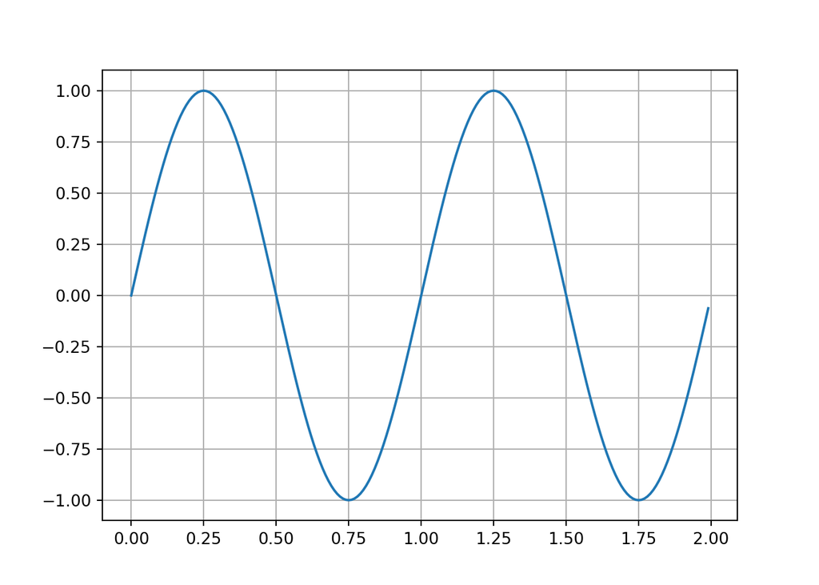

```python
import os
os.environ['QT_QPA_PLATFORM_PLUGIN_PATH'] = 'C:/Users/learningmachine/AppData/Local/Continuum/anaconda3/Library/plugins/platforms'
import numpy as np
import matplotlib.pyplot as plt
import pandas as pd
x = np.arange(0.0,2,0.01)
y = np.sin(2* np.pi*x)
plt.plot(x,y)
plt.grid(True)
plt.show()
```

```python
data = pd.DataFrame({'x':x,'y':y})
```

A pandas dataframe can also be used within R.

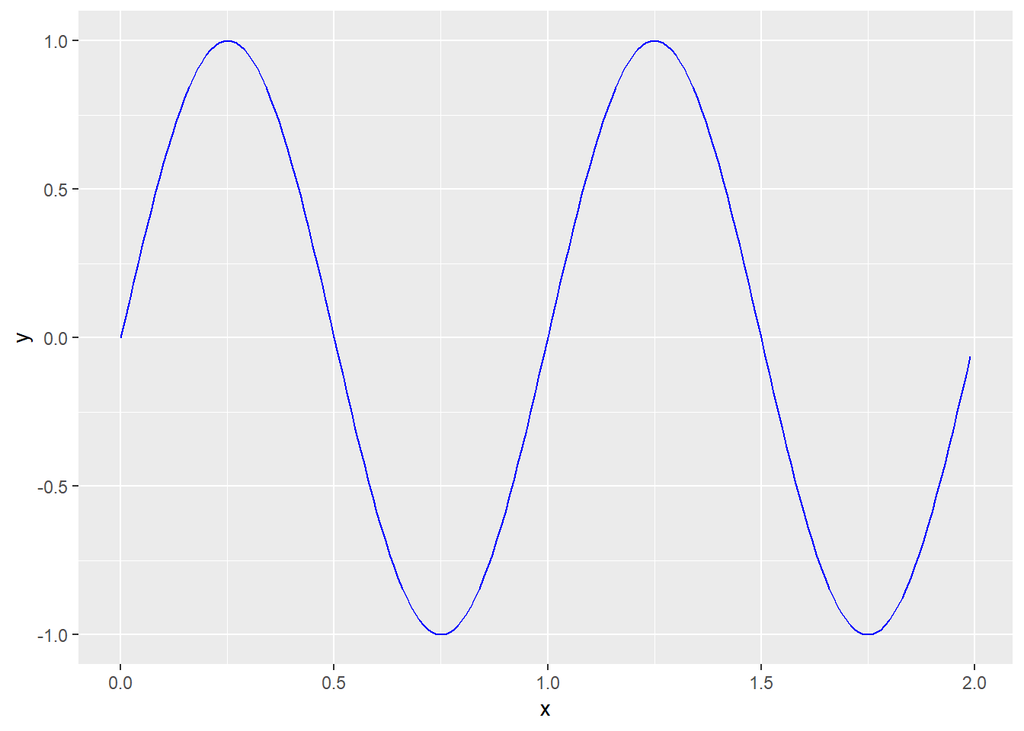

```r
library(ggplot2)
ggplot(py$data,aes(x,y))+ geom_line(col='blue')
```

### Stan

The following is a Bayesian inference procedure in Stan to infer the bias of a coin from data

```r
library(rstan)
rstan_options(autowrite=TRUE)

set.seed(0)
N <- 100 # Number of observations
y <- rbinom(N ,1,prob=0.8) ##Simulate N obs from a biased coin
dataList <- list(y=y,N=N)
```

```stan
// The input data is a vector 'y' of length 'N'.
data {
  int<lower=0> N;
  int y[N];
}

// The parameters accepted by the model. Our model
// accepts one parameters 'theta' to be estimated.
parameters {
  real<lower=0,upper=1> theta;
}

// The model to be estimated. We model the output
// 'y' to be normally distributed with mean 'mu'
// and standard deviation 'sigma'.
model {
  theta ~ beta(1,1); // Weak prior
  y ~ bernoulli(theta);
}
```

Now generate a posterior

```r
###Use multiple cores if available
options(mc.cores = parallel::detectCores()-1)


# Generate posterior sample:

if(!exists('stanFit')){
stanFit <- sampling( object=coin ,
                     data = dataList ,
                     chains = 3 ,
                     iter = 1000 ,
                     warmup = 200 ,
                     thin = 1 )
}
```

Plot the posterior

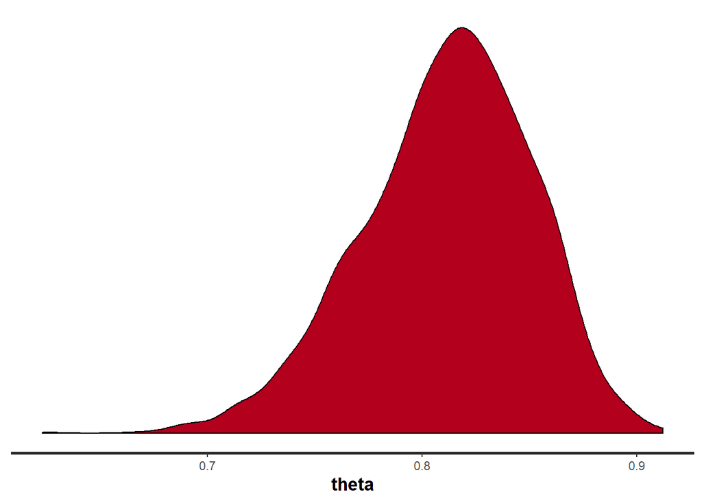

```r
stan_dens(stanFit)
```

## gganimate

Package for animated graphics which extends ggplot2. Additional dependencies will have to be installed.

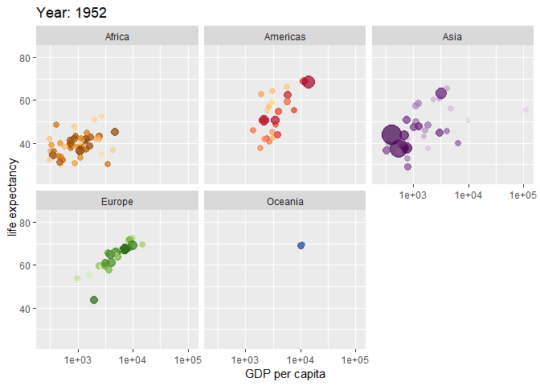

```r
library(gapminder)
library(gganimate)


p <- ggplot(gapminder, aes(gdpPercap, lifeExp, size = pop, colour = country)) +
  geom_point(alpha = 0.7, show.legend = FALSE) +
  scale_colour_manual(values = country_colors) +
  scale_size(range = c(2, 12)) +
  scale_x_log10() +
  facet_wrap(~continent) +
  # Here comes the gganimate specific bits
  labs(title = 'Year: {frame_time}', x = 'GDP per capita', y = 'life expectancy') +
  transition_time(year) +
  ease_aes('linear')

animate(p)
```

## rayshader

This is possibly the coolest package ever. According to the documentation:

*rayshader uses a combination of raytracing, spherical texture mapping, lambertian reflectance, and ambient occlusion to produce hillshades of elevation matrices. Includes water detection and layering functions, programmable color palette generation, several built-in textures, 2D and 3D plotting options, and the ability to export 3D maps to a 3D printable format.*

```r
library(rayshader)

montereybay %>%
sphere_shade(texture="imhof2") %>%
plot_3d(montereybay, zscale=50, water = TRUE, watercolor="imhof2",
waterlinecolor="white", waterlinealpha=0.5)
```

```
##
Calculating Surface Normal [-----------------------------------] ETA:  0s
Calculating Surface Normal [===================================] ETA:  0s
```

## Miscellaneous

### Sunburst Charts

Pretty cool visualization for representing hierarchical data using concentric circles.

```r
library(sunburstR)
sequences <- read.csv(
  system.file("examples/visit-sequences.csv",package="sunburstR")
  ,header=F
  ,stringsAsFactors = FALSE
)

sunburst(sequences)
```

[interactive chart not shown]

## Other useful/interesting resources

1. Best practices for naming files: https://speakerdeck.com/jennybc/how-to-name-files?slide=27
2. mlflow for tracking ML experiments,sharing and deploying : https://www.mlflow.org/docs/latest/tutorial.html
3. All the risk calculators at http://riskcalc.org/ were built by Cleveland Clinic using Shiny